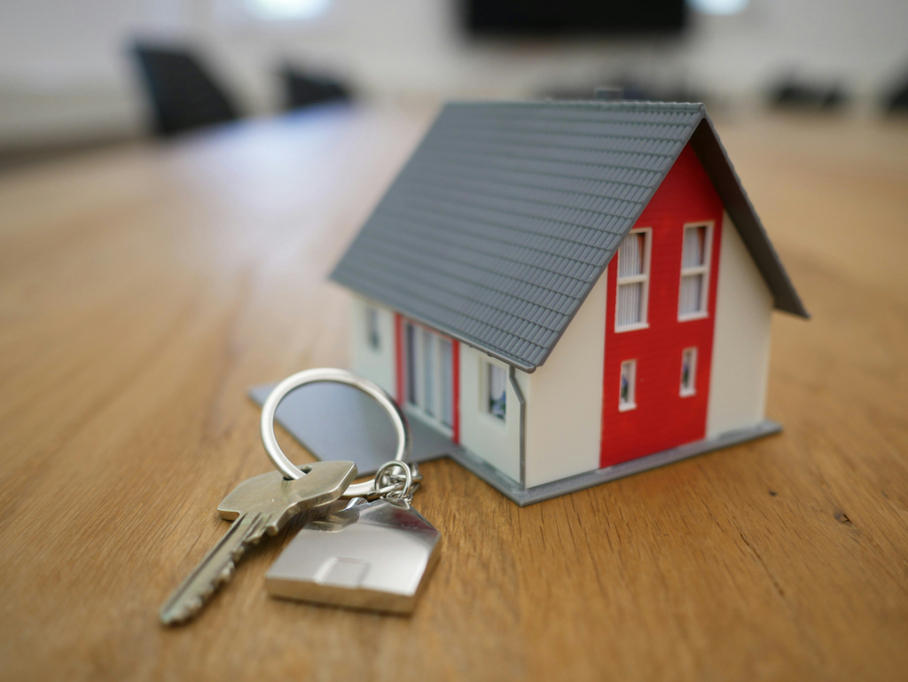

### [*Click to view the analysis*](https://business-analytics-slee.shinyapps.io/Data_Models_Decisions_Chapter_1_buying_a_house/)

## **Take a quick glance of this case study and analysis.**

**What kind of problem are we solving, what is the story?**

We are solving a decision analysis problem to help Debbie and George Calvert decide the best offer to make on a house listed at $400,000 in Shaker Heights, Ohio. The couple is emotionally attached to the house and faces competition from multiple potential buyers. They need to decide whether to offer $390,000, $400,000, or $405,000, considering probabilities of acceptance based on whether they are the only bidders or if a bidding war ensues. Their broker has advised them to bid close to the asking price to stay competitive, adding complexity to their decision.

**What is the goal of the analysis?**

The goal is to build and analyze a decision tree that outlines Debbie and George’s possible offer strategies, factoring in the likelihood of competing bids and the potential outcomes. By calculating the Expected Monetary Value (EMV) for each option, the analysis aims to identify the strategy that maximizes their perceived value while minimizing financial risk, ultimately guiding them toward the optimal bidding decision.

Copyright © 2023- 2025 Sangho Lee, All rights reserved.